# Midterm

## Proof Ingredients

- supplementary interior angles add to $180^\circ$
- definition of supplementary angles : together they make a straight angle (add to $180^\circ$)
- congruence and angle measure theorem

Proof :

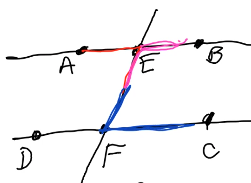

Let our first angle be $\angle AEF$, and our 2nd be $\angle EFC$.

(“Our goal is to say something about their measure”)

$\angle BEF$ and $\angle AEF$ are supplementary, so $m\angle BEF + m\angle AEF=180^\circ$.

(“What can we say about the pink and blue angle”)

Since $\overline{AB}$ and $\overline{DC}$ are parallel the supplementary interior angles $\angle BEF$ and $\angle BFC$ have measure that add to $180^\circ$ by the theorem for supplementary interior angles.

- $m\angle AEF + m\angle BEF = 180^\circ$
- $m\angle BEF + m\angle EFC = 180^\circ$

So $m\angle AEF + m\angle BEF = m\angle BEF + m\angle EFC$ and $m\angle AEF = m\angle EFC$.

By the Congruence and Angle measure Theorme, $\angle AEF \cong \angle EFC$.

## Triangles

Triangles: Consist of 3 straight line segments meeting in 3 vertices.

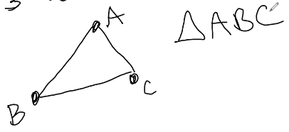

### Types

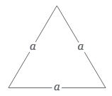

Equilateral: All 3 sides have the same length

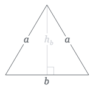

Isosceles: 2 sides are the same length

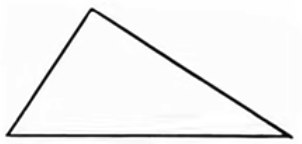

Scalene: all sides are different

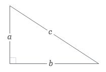

Right: Has a $90^\circ$ angle in it.

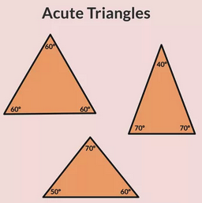

Acute: All angles are less than $90^\circ$.

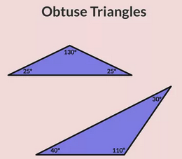

Obtuse: 1 angle is more than $90^\circ$

### Theorem: Angles inside a triangle add to $180^\circ$

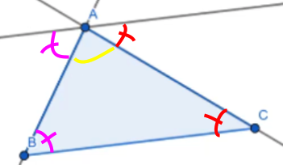

Proof:

The top line (that touches the top of the triangle at A) is running parallel to the base of the triangle.

Notice that the pink angles are the same, and the red angles are the same.

This indicates that the pink angle + the yellow angle + the red angle = a straight angle which is $180^\circ$.

Therefore $m\angle ABC + m\angle BCA +m\angle CAB=180^\circ\quad\quad\square$.

### Thm (SAS)

Suppose $\triangle ABC$ and $\triangle EDF$ satisfy:

- $\overline{AB}\cong\overline{DE}$ (side)
- $\angle ABC \cong \angle DEF$
- $\overline{BD}\cong\overline{EF}$ (side)

Then $\triangle ABC \cong \triangle DEF$.

Proof :

(Note that nothing *about* picture can be in your proof. i.e. can’t say because two things look the same in a picture … )

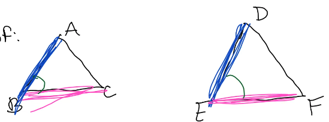

We know that:

- $\overline{AB}\cong\overline{DE}$
- $\overline{BC}\cong\overline{EF}$
- $\angle{ABC}\cong\angle{DEF}$

We know there is an isometry f that takes $\overline{AB}$ and superimposes it on $\overline{DE}$.

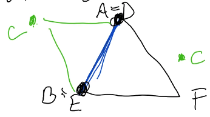

- “Lets agree that if C=F then we are done, b what happens if C is on the opposite side of f?”

If C and F are on opposite sides of $\overline{AB}$ after f, do reflection g over $\overline{AB}$.

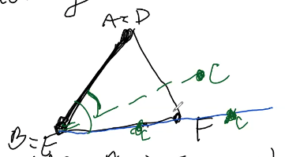

Since $\angle ABC \cong \angle DEF$, c must lie on $\overrightarrow{EF}$.

Since $\overline{BC}\cong \overline{EF}$ they have the same length so c lies on F after f, g.

Therefore $\triangle ABC\cong \triangle DEF\quad\quad\quad\square$.

We $\underline{\text{have}}$ SAS (side angle side)

There are

- ASA (angle side angle)
- AAS (angle angle side)
- SSS (side side side)

There is not a $SSA$.

# W4D7: Jan. 25th, 2022

Quiz’s will be graded by Wednesday and Thurseday.

- taking time to give a lot of feedback

Homework 1 Solutions will be posted today after class

- HW2 Solutions will be posted next Tuesday
- Professors solutions may be different than ours

Boyce Notes will have all of our definitions and theorems that we can use.

Thursday we will discuss the midterm.

## Homework 2

1. $A=B$, $AB=0$

Conj: If $A=B$ then $AB=0$.

Proof: Suppose by way of contradiction (BWOC) that $AB\ne 0$.

Then $AB>0$.

Suppose we choose C so B is between A and C.

Then $AB+BC=AC$ (length axiom 3)

$\Rightarrow AB+BC=BC$ (A=B)

$\Rightarrow AB=0$ (subtract $BC$ from both sides)

This contradicts our assumption that $AB>0$. So $AB=0$. $\quad\quad \square$

2. $A=C$, $m\angle ABC=0$

$\angle ABC$, A,C are equal.

$\Rightarrow m\angle ABC$.

Imagine you have $\angle ABC$, and imagine there is an $\angle DBC$

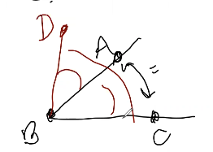

- D could also be and angle bisector

$m\angle BDC = m\angle DBA+m\angle ABC$

- whereever you see a C or A you are allowed to replace it with the other one.

$\Rightarrow m\angle BDC = m\angle DBC+m\angle ABC$

$\Rightarrow 0=m\angle ABC$.

Email homework corrections by next Monday.

## Quadrilaterals

4 sided figure in the plane (drawn on a flat surface), where the edges are straight lines.

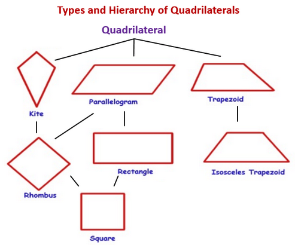

### Parallelogram

Both pairs of opposite sides are parallel

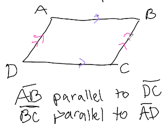

### Trapezoid

At least 1 pair of opposite sides is parallel.

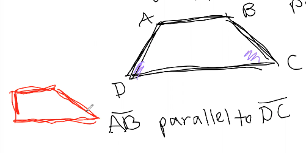

### Rhombus

Parallelogram, all sides are same length

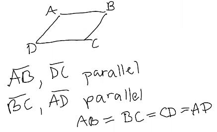

### Rectangle

Parallelogram (whose opposite sides have equal length) whose internal angles are all right angles.

### Square

Rectangle whose sides are all equal length.

## Parallelogram Thm

(part 4 of Boyce Notes)

Let ABCD be a parallelogram. The following are equivalent:

1. ABCD is a parallelogram. (opposite sides are parallel)
2. $\angle DAB \cong \angle BCD$ and $\angle ABC\cong \angle CDA$ (angles that are across from each other are congruent)
3. $AB=CD$ and $BC=DA$ (opposite sides have equal measure)
4. $\overline{AC}$ and $\overline{BD}$ bisect each other. (diagnals bisect each other)

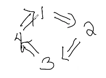

Meaning, we only need to prove four parts.

### Toolkit

- Euclid’s 5th axiom
- Angles and parallel lines
  - vertical angles are congruent
  - alternate interior angles are congruent
  - corresponding angles are congruent
  - supplementary anglesa add to 180
- Triangles : Angles add to 180
  - Congruence: SAS, ASA,SSS, AAS

### Proof - part 1

$1\Rightarrow 2$ : If ABCD is a parallelogram then

- $\angle DAB\cong \angle BCD$
- $\angle ABC\cong \angle CDA$

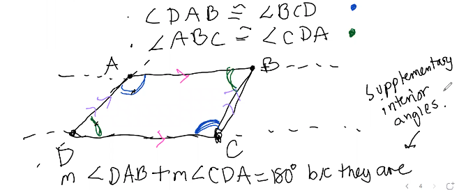

We also know,

$m\angle ABC+m\angle BCD=180^\circ$ (1)

$m\angle DAB+m\angle ABC=180^\circ$ (2)

$m\angle BCD+m\angle CDA=180^\circ$ (3)

$m\angle DAB+m\angle CDA=180^\circ$ (4) (written on pictures)

All of these hold because they are supplementary interior angles.

Using these equations,

$m\angle BCD=180^\circ -m\angle ABC=m\angle DAB$

By the congruence and angle measure theorem $\angle DAB\cong \angle BCD$.

Similarly

$m\angle ABC=180^\circ -m\angle BCD=m\angle CDA$

### Proof - part 2

($s\Rightarrow 3$) ABCD is a quadrilateral.

If $\angle DAB\cong \angle BCD$ and

$\angle ABC\cong \angle CDA$ then

$AB=CD$ and $BC=DA$

(we don’t know anything about parallel, so we will use our triangle theorems)

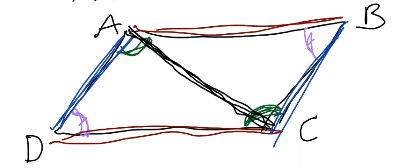

$\triangle ABC$ and $\triangle CDA$

- It is important the order of the letters for triangles
- want $\overline{AB}$ to match $\overline{CD}$
- and $\overline{BC}$ to match $\overline{DA}$

We know that $AC=CA$ and that $\angle ABC\cong \angle CDA$ …

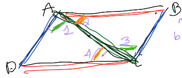

“What can we say about $\angle$ 1, 2, 3, and 4”

$m\angle 1+m\angle 2 = m\angle 3+m\angle 4$ by assumption.

We also know $m\angle ABC+ m\angle 2 + m\angle 3=180^\circ$ and

$m\angle CDA+ m\angle 1 + m\angle 4=180^\circ$

We can also say,

$m\angle 2+m\angle 3=180^\circ-m\angle ABC$

$m\angle 1+m\angle 4=180^\circ-m\angle CDA$

So, $(m\angle 2+m\angle 3=m\angle 1+m\angle 4)$

Also, $(m\angle 1+m\angle 4=m\angle 2+m\angle 3)$

Then, $(m\angle 2+m\angle 3=m\angle 1+m\angle 4)-(m\angle 1+m\angle 4=m\angle 2+m\angle 3)$

$\Rightarrow = m\angle 3-m\angle 1=m\angle 1-m\angle 3$

$\Rightarrow = 2m\angle 3=2m\angle 1 - m\angle 3= m\angle 1$

Now we can say that $\triangle ABC \cong \triangle CDA$, hence their sides have the same lengths. Therefore $AB=CD$ and $BC=DA$.

# W4D8: Jan. 27th, 2022

Midterm will be during class on Thurseday, and can be taken remotely.

Remote Exam Two Options:

1. Email before exam so we can print
2. Post at start of Exam, and look at it on screen.

Everyone will need to be on zoom with camera on.

Midterm will go through triangle theorm stuff, meaning non of the parallelorgram stuff will be on the midterm.

Next class will be half review, and half new material.

## Practice Problems

1. Is “x divides y evenly” a model for the following Axiom System:
- 2 is better than 8
- 3 is better than 9
- If x is better than y and y is better than z then x is better than z.

True or False (explain your answers):

- If 2 lines segments are congruent then one is a translation of the other in the plane.
- If <ABC and <CBD are supplementary then B is between A and D.
- The negation of “If it is snowing then it is cold” is “If it is not cold then it is not snowing.”

Finish this proof:

- Claim: Alternate interior angles are congruent.
- Proof: Suppose AB and CD are parallel, E is between A and B, and F is between C and D. We will show that <AEF is congruent to <DFE.
- Because <AEF and <BEF are supplementary, then their measures add to 180 degrees.
- Because (fill in the blank), the measure of <BEF and <DFE add to 180 degrees.
- Then m<AEF+m<BEF=m<BEF + m<DFE so m<AEF = m<DFE.
- So because (fill in the blank), <AEF and <DFE are congruent.

Prove that if BD is a bisector of <ABC, then m<ABD = (½)m<ABC.

## HW 3 (Due Week 4)

If ABCD is a parallelogram ABCD is a rectangle $\Leftrightarrow$ $\overline{AC}$ and $\overline{BD}$ are congruent.

- know it’s a parallelogram, and everything in that theorem
  - opposite angles are congruent
  - opposite sides have the same length
  - diagnols bisect each other

Claim: If $\overline{AC}\cong \overline{BD}$ then ABCD is a rectangle.

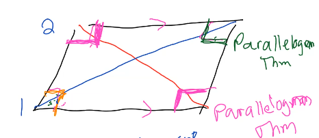

If we know that the orange angle is a right angle then we also know that the green angle is a right angle because of the parallelogram theorem that says opposite angles are congruent.

We also know that if the orange angle is then the pink angle on the same side is also a right angle becasue same side interior angles add up to 180.

The remaining pink angle is also a right angle becasue of the parallelorgram theorem that says opposite angles are congruent.

Hint : $m\angle 1+m\angle 2 = 180$, can you show that $\angle 1\cong\angle 2$. If you could show that, then that would tell us that they both have the same measurement of 90 degrees because two things that are the same size that add up to 180 are 90.

Note: This is the sort of “large proof” that wouldn’t be on the exam. Something we spend a week on, not just do in an hour.

## Last Class: Parallelogram Theorem Proof

ABCD is a parallelogram. Then the following are equivalent that the folloing are equivalent (TFAE).

Let ABCD be a parallelogram. The following are equivalent:

1. ABCD is a parallelogram. (opposite sides are parallel)
2. $\angle DAB \cong \angle BCD$ and $\angle ABC\cong \angle CDA$ (angles that are across from each other are congruent)
3. $AB=CD$ and $BC=DA$ (opposite sides have equal measure)
4. $\overline{AC}$ and $\overline{BD}$ bisect each other. (diagnals bisect each other)

Last class we proved

- 1 $\Rightarrow$ 2
- 2 $\Rightarrow$ 3

Now we need to prove

- 3 $\Rightarrow$ 4
- 4 $\Rightarrow$ 1

Then everything implies everything.

### 3 $\Rightarrow$ 4

Suppose $AB=CD$, $BC=DA$

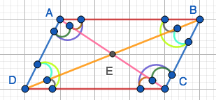

Want to show: $\overline{CD}$, $\overline{BD}$ bisect each other.

In other words: $AE=EC$, $DE=EB$

By SSS, $\triangle ABD \cong \triangle CDB$ and $\triangle ABC\cong \triangle CDA$

By ASA $\triangle AED \cong \triangle CEB$

$\Rightarrow AE=CE$, $DE=BE$

### 4 $\Rightarrow$ 1

If $\overline{AC}$, $\overline{BD}$ bisect each other then ABCD is a parallelogram.

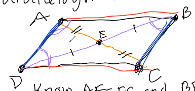

Know $AE=EC$ and $BE=ED$

Suppose $AC$, $BD$ bisect each other.

Vertical angle theorem $\Rightarrow$ $\angle AED\cong \angle BEC$, $\angle AEB\cong \angle CED$.

SAS $\Rightarrow \triangle AED\cong \triangle CEB$ and $\triangle AEB\cong \triangle CED$.

[figure not shown]

Want: $m\angle 1 +m\angle 2 + m\angle 3 + m\angle 4=180^\circ$

$m\triangle ACD= m\angle 1 +m\angle 2 + m\angle 3 + m\angle 4=180^\circ$

$\Rightarrow$ By Euclid’s 5th axiom since the supplementary interior angles for $\overline{AB}$ and $\overline{CD}$ add to $180^\circ$, $\overline{AB}$ is parallel to $\overline{CD}$. Same argument $\overline{AD}$m $\overline{BC}$ are parallel.

Activity 1: Use the axioms of area to prove that the area of a trapezoid is the product of its height and the arithmetic mean of its bases.

## Axioms of Area

1. To every polygonal region (space enclosed by straight lines in the plane) there corresponds a unique positive number called $\underline{area}$.
2. If 2 tirangles are congruent their areas are equal.
3. If $R=R_1\cup R_2$ and $R_1\cap R_2$ is a finite number of segments or points, then the area of $R$ is the sum of the areas of $R_1+R_2$.
4. The area of a rectangle is its base times its height.

## Ex:

Conjecture: The area of a parallelogram ABCD is $AB=CX$ where $X$ is on the $\overleftrightarrow{AB}$ and $\overleftrightarrow{CX}$ is perpendicular to $\overleftrightarrow{AB}$.

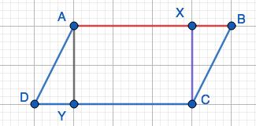

Axiom 3: Area ($\triangle AYD$) + Area($AXCY$) + Area ($\triangle BXC$) = Area($ABCD$) (equation 1)

Axiom 4: Area(AXC) = $AC\cdot CX$.

Axiom 2: $\triangle AYD\cong \triangle CXB$ then areas are equal.

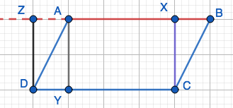

Put Z on $\overleftrightarrow{AB}$ so that $\overline{DZ}$ is perpendicular to $\overleftrightarrow{AB}$.

Area(AZDY) = Area($\triangle AZD$) + Area($\triangle AYD$)

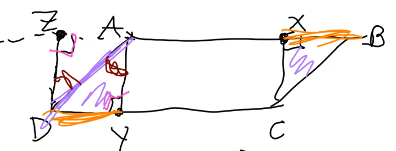

AAS $\Rightarrow$ 2Area($\triangle AZD$)

$AY\cdot DY=2 Area(\triangle AYD)$

Parallelogram :

- Rectangle: $AX\cdot CX$
- Triangle: $\frac{1}{2}(AY\cdot DY)$

Equation 1: Area ($\triangle AYD$) + Area($AXCY$) + Area ($\triangle BXC$) = Area($ABCD$)

$\Rightarrow AX\cdot CX+(\frac{1}{2}(AY\cdot DY))+(\frac{1}{2}(AY\cdot DY))=AB\cdot CX$

$\Rightarrow AX\cdot CX+CX\cdot DY=AB\cdot CX$

$\Rightarrow AX\cdot CX+XB\cdot CX$

$\Rightarrow (AX+XB)CX$

- $(AX+XB)$ Line segment, axiom 3

## Circle Prep.

How do we get the area of a circle?

- Can you cut a circle into areas of squares and triangles?

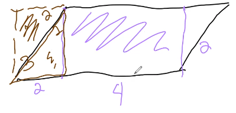

- Begin to reach a problem in calculus called a limit.

# W5D9: Feb. 1st, 2022

Homework 3 is graded, and homework 2 solutions are available in Canvas.

Write answers on a seperate sheet of paper, and supmit to canvas.

## Axioms of Area

1. Every polygon region has $\underline{\text{area}}$.
2. If 2 triangels are congruent then their areas are equal.
   - (this is important)
3. $R=R_1\cup R_2$ and $R_1\cap R_2$ is a finite set of segments/ points, area ($R_1$) + area ($R_2$) = area R.
4. Area of rectangle is base $\times$ height.

## Area of a paralelogram

Last time we showed the area of a parallelogram. We had a couple strategies.

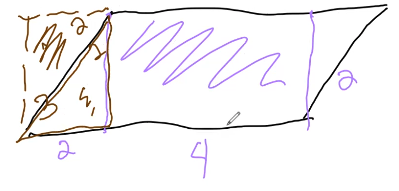

- cut area into two triangels and a rectangle.
- used area axiom 4
- then showed two triangles are congruent
- used area axiom 2
- extended line and showed two triangles and used axiom 2 and 3

## Homework 4

Area of triangle formula.

On homework we can use:

- use axioms
- use parallelogram formula (showed together)
- use previous problems

## Practice: Area of a trapezoid

For trapezoids, we have 1 set of parallel lines (or more).

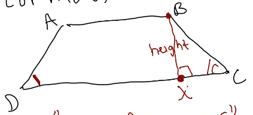

Find the area of a trapezoid.

Aim: height $\times$ “mean of the bases” : $\frac{AB+CD}{2}$

$AB\cdot H+\frac{1}{2}CX\cdot H+\frac{1}{2}DY\cdot H=H(AB+\frac{1}{2}CX+\frac{1}{2}DY)$

End goal : $H(\frac{1}{2}(AB+CD))$

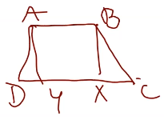

You can notice that $DC-AB=CX+DY$, and use a substitution to get where you want to go.

Another way to look at this:

$=H(\frac{1}{2}AB+\frac{1}{2}AB+\frac{1}{2}CX+\frac{1}{2}DY)$

$=H(\frac{1}{2}(AB+AB+CX+DY))$, notice $AB+CX+DY=CD$

Therefore $H(\frac{1}{2}(AB+CD))$.

This is how the homework is, and now we can use area of trapezoid.

## Similarity

Isometries: reflect, rotate, translate

- don’t change lengths or angles

$\rightarrow$ Congruence

Idea for similarity: proportional

$\rightarrow$ Dilation - pick a center point and either shrink or expand

Imagine we pick a point p, then we move on a straight line towards p or expand away from P.

Pick a “scaling factor” $K>0$.

- If K is less than 1: shrink
- If K is larger than 1: expanding
- If K = 1, Do nothing

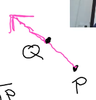

Pick center P, where does Q go?

- Draw a line segment $\overline{QP}$
- Dilation has caling factor k, move Q to Q’ so that $Q'P=kQP$
- Pick $Q'$ on $\overrightarrow{PQ}$ with that distance

Similarity: 2 figures are similar if one can be superimposed on the other by a dilation and a sequence of isometries.

Next: AAA Theorem (similar triangels)

- do a diaation and then some congruence

## Midterm Review

No geometric inequalities or quadrilaterials.

Wont be given new axioms.

Material Covered:

- Week 1
  - What’s an inverse and a converse
- Week 2
  - parallel lines
  - angles
- Week 3
  - triangles

Want:

Types of Questions

1. True / False (full page)
- where you have to explain choice. (Not a proof)
2. Fill in the proof. (2)
- need to fill in a theorem or algebra step
- look at picture and tell why …
3. Proofs (2)
- one short
- one medium (like homework)

## Practice Questions

(week 5 google doc)

### Round 1: True or False

If ABC and DEF are triangles, with <ABC congruent to <DEF, AB = DE, and BC = EF, then ABC and DEF are congruent.

- True, SAS

If ABC and DEF are triangles, with <ABC congruent to <DEF, AC = DF, and BC = EF, then ABC and DEF are congruent.

- False, ASS is not a $\triangle$ congruence

The negation of “If a dragon is red then it breathes fire” is “If a dragon is red then it does not breathe fire.”

- False, the negation would be “A dragon can be red, and not breathe fire”.

The contrapositive of “If a dragon is red then it breathes fire” is “If a dragon is not red then it does not breathe fire.”

- False, this is the inverse. The Contrapositive would be “If a dragon does not breathe fire, then it is not red”.

### Round 2: Fill in the Proof

Claim: Alternate interior angles are congruent.

Claim: If A=B then AB = 0.

Proof: Suppose A=B. Choose another point C. By Axiom 3 of Measure for Line Segments, AC = AB + BC. (missing step: BC = AB + BC) So AB = 0.

### Round 3: Definitions and Theorems

Vertical angles are congruent.

Alternate Exterior Angles are congruent.

The AAS Theorem states that if two angles and any side of one triangle are congruent to two angles and any side of another triangle, then the triangles are congruent.

An isometry preserves angles and distances.

# W5D10: Feb. 3rd, 2022

**MIDTERM**